← Probabilistic Machine Learning

# Matrix-Vector Multiplication: Geometric Transformations

When a matrix multiplies a vector, it **transforms** that vector:

$$\mathbf{y} = \mathbf{A} \mathbf{x}$$

This is one of the most powerful ideas in linear algebra. Matrices can:

- **Rotate** vectors
- **Scale** (stretch/shrink) vectors
- **Shear** (skew) vectors
- **Project** vectors onto subspaces
- **Reflect** vectors

Understanding this geometrically is the key to intuition about covariance transformations, neural networks, and much more.

```python
import numpy as np
import matplotlib.pyplot as plt
from matplotlib.patches import FancyArrowPatch, Circle, Polygon
from matplotlib.collections import PatchCollection

np.random.seed(42)
plt.rcParams['figure.figsize'] = (12, 6)
plt.rcParams['font.size'] = 11
```

## 1. Two Ways to Think About $\mathbf{A}\mathbf{x}$

### View 1: Row-by-Row (Dot Products)

Each element of the output is a **dot product** of a row of $\mathbf{A}$ with $\mathbf{x}$:

$$\begin{pmatrix} a_{11} & a_{12} \\ a_{21} & a_{22} \end{pmatrix} \begin{pmatrix} x_1 \\ x_2 \end{pmatrix} = \begin{pmatrix} a_{11}x_1 + a_{12}x_2 \\ a_{21}x_1 + a_{22}x_2 \end{pmatrix}$$

### View 2: Column-by-Column (Linear Combination)

The output is a **weighted sum of columns** of $\mathbf{A}$:

$$\mathbf{A}\mathbf{x} = x_1 \begin{pmatrix} a_{11} \\ a_{21} \end{pmatrix} + x_2 \begin{pmatrix} a_{12} \\ a_{22} \end{pmatrix}$$

```python
# Both views give the same result
A = np.array([[2, 1],
              [1, 3]])
x = np.array([3, 2])

# View 1: Row dot products
y1 = np.array([A[0] @ x, A[1] @ x])

# View 2: Column linear combination
y2 = x[0] * A[:, 0] + x[1] * A[:, 1]

# Standard way
y = A @ x

print("Matrix A:")
print(A)
print(f"\nVector x = {x}")
print(f"\nView 1 (row dot products):")
print(f"  y[0] = [2, 1] · [3, 2] = 2×3 + 1×2 = {y1[0]}")
print(f"  y[1] = [1, 3] · [3, 2] = 1×3 + 3×2 = {y1[1]}")
print(f"\nView 2 (column combination):")
print(f"  y = 3×[2, 1] + 2×[1, 3]")
print(f"    = [6, 3] + [2, 6]")
print(f"    = {y2}")
print(f"\nResult: y = {y}")
```

```
Matrix A:
[[2 1]
 [1 3]]

Vector x = [3 2]

View 1 (row dot products):
  y[0] = [2, 1] · [3, 2] = 2×3 + 1×2 = 8
  y[1] = [1, 3] · [3, 2] = 1×3 + 3×2 = 9

View 2 (column combination):
  y = 3×[2, 1] + 2×[1, 3]
    = [6, 3] + [2, 6]
    = [8 9]

Result: y = [8 9]
```

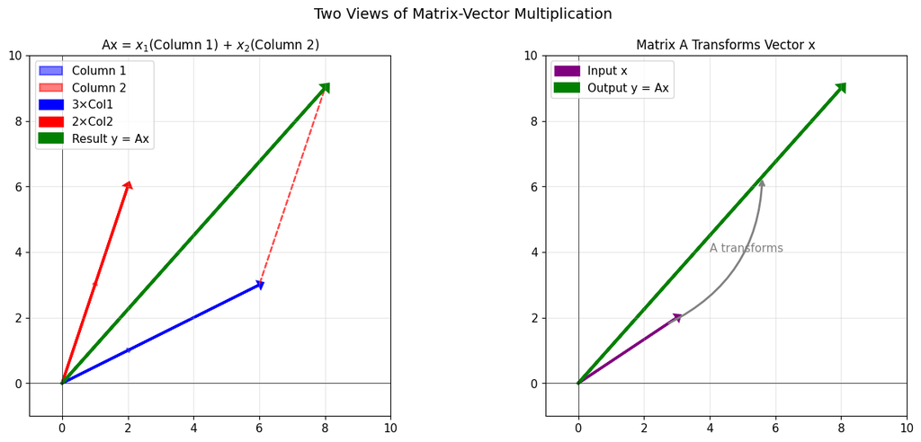

```python
# Visualize the column combination view
fig, axes = plt.subplots(1, 2, figsize=(14, 6))

# Left: Show the column vectors and their weighted sum
ax1 = axes[0]
col1 = A[:, 0]
col2 = A[:, 1]

# Draw column vectors (unscaled)
ax1.arrow(0, 0, col1[0], col1[1], head_width=0.15, head_length=0.1,
          fc='blue', ec='blue', linewidth=1.5, alpha=0.5, label='Column 1')
ax1.arrow(0, 0, col2[0], col2[1], head_width=0.15, head_length=0.1,
          fc='red', ec='red', linewidth=1.5, alpha=0.5, label='Column 2')

# Draw scaled column vectors
scaled1 = x[0] * col1
scaled2 = x[1] * col2
ax1.arrow(0, 0, scaled1[0], scaled1[1], head_width=0.2, head_length=0.12,
          fc='blue', ec='blue', linewidth=2.5, label=f'{x[0]}×Col1')
ax1.arrow(0, 0, scaled2[0], scaled2[1], head_width=0.2, head_length=0.12,
          fc='red', ec='red', linewidth=2.5, label=f'{x[1]}×Col2')

# Draw the sum (shift scaled2 to tip of scaled1)
ax1.arrow(scaled1[0], scaled1[1], scaled2[0], scaled2[1], head_width=0.15, head_length=0.1,
          fc='red', ec='red', linewidth=1.5, linestyle='--', alpha=0.7)
ax1.arrow(0, 0, y[0], y[1], head_width=0.25, head_length=0.15,
          fc='green', ec='green', linewidth=3, label='Result y = Ax')

ax1.set_xlim(-1, 10)
ax1.set_ylim(-1, 10)
ax1.set_aspect('equal')
ax1.grid(True, alpha=0.3)
ax1.axhline(y=0, color='black', linewidth=0.5)
ax1.axvline(x=0, color='black', linewidth=0.5)
ax1.legend(loc='upper left')
ax1.set_title('Ax = $x_1$(Column 1) + $x_2$(Column 2)', fontsize=12)

# Right: Show transformation of input vector
ax2 = axes[1]
ax2.arrow(0, 0, x[0], x[1], head_width=0.2, head_length=0.12,
          fc='purple', ec='purple', linewidth=2.5, label='Input x')
ax2.arrow(0, 0, y[0], y[1], head_width=0.25, head_length=0.15,
          fc='green', ec='green', linewidth=3, label='Output y = Ax')

# Draw a curved arrow showing transformation
ax2.annotate('', xy=(y[0]*0.7, y[1]*0.7), xytext=(x[0]*0.9, x[1]*0.9),
             arrowprops=dict(arrowstyle='->', connectionstyle='arc3,rad=0.3',
                           color='gray', lw=2))
ax2.text(4, 4, 'A transforms', fontsize=11, color='gray')

ax2.set_xlim(-1, 10)
ax2.set_ylim(-1, 10)
ax2.set_aspect('equal')
ax2.grid(True, alpha=0.3)
ax2.axhline(y=0, color='black', linewidth=0.5)
ax2.axvline(x=0, color='black', linewidth=0.5)
ax2.legend(loc='upper left')
ax2.set_title('Matrix A Transforms Vector x', fontsize=12)

plt.suptitle('Two Views of Matrix-Vector Multiplication', fontsize=14)
plt.tight_layout()
plt.show()
```

## 2. Geometric Transformations

Different matrices create different geometric effects. Let's visualize each type.

```python
def plot_transformation(ax, A, title, original_color='blue', transformed_color='red'):
    """Plot how a matrix transforms a set of points."""
    # Create a grid of points (unit circle + some radial lines)
    theta = np.linspace(0, 2*np.pi, 100)
    circle = np.array([np.cos(theta), np.sin(theta)])

    # Transform the circle
    transformed = A @ circle

    # Plot original and transformed
    ax.plot(circle[0], circle[1], color=original_color, linewidth=2, alpha=0.5, label='Original')
    ax.plot(transformed[0], transformed[1], color=transformed_color, linewidth=2, label='Transformed')

    # Plot basis vectors and their transforms
    e1 = np.array([1, 0])
    e2 = np.array([0, 1])

    ax.arrow(0, 0, e1[0]*0.9, e1[1], head_width=0.1, fc=original_color, ec=original_color, alpha=0.5)
    ax.arrow(0, 0, e2[0], e2[1]*0.9, head_width=0.1, fc=original_color, ec=original_color, alpha=0.5)

    Ae1 = A @ e1
    Ae2 = A @ e2
    ax.arrow(0, 0, Ae1[0]*0.9, Ae1[1]*0.9, head_width=0.12, fc=transformed_color, ec=transformed_color)
    ax.arrow(0, 0, Ae2[0]*0.9, Ae2[1]*0.9, head_width=0.12, fc=transformed_color, ec=transformed_color)

    ax.set_xlim(-2.5, 2.5)
    ax.set_ylim(-2.5, 2.5)
    ax.set_aspect('equal')
    ax.grid(True, alpha=0.3)
    ax.axhline(y=0, color='black', linewidth=0.5)
    ax.axvline(x=0, color='black', linewidth=0.5)
    ax.set_title(title, fontsize=11)
    ax.legend(loc='upper left', fontsize=8)
```

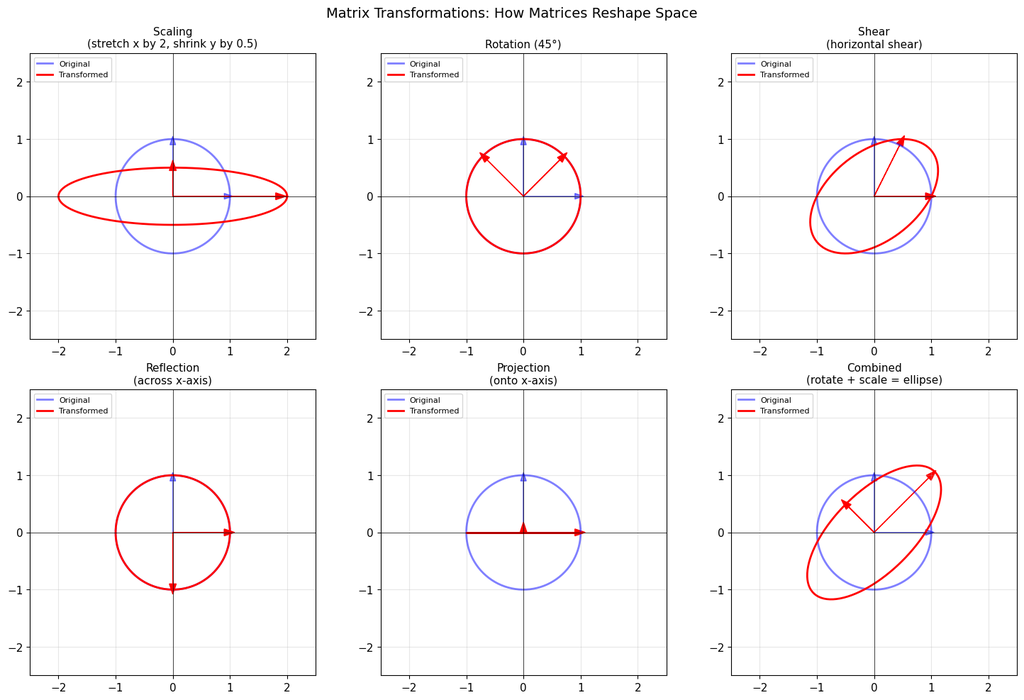

```python
# Different types of transformations
fig, axes = plt.subplots(2, 3, figsize=(15, 10))

# 1. Scaling
A_scale = np.array([[2, 0], [0, 0.5]])
plot_transformation(axes[0, 0], A_scale, 'Scaling\n(stretch x by 2, shrink y by 0.5)')

# 2. Rotation (45 degrees)
theta = np.pi/4
A_rotate = np.array([[np.cos(theta), -np.sin(theta)],
                     [np.sin(theta), np.cos(theta)]])
plot_transformation(axes[0, 1], A_rotate, 'Rotation (45°)')

# 3. Shear
A_shear = np.array([[1, 0.5], [0, 1]])
plot_transformation(axes[0, 2], A_shear, 'Shear\n(horizontal shear)')

# 4. Reflection
A_reflect = np.array([[1, 0], [0, -1]])
plot_transformation(axes[1, 0], A_reflect, 'Reflection\n(across x-axis)')

# 5. Projection
A_project = np.array([[1, 0], [0, 0]])
plot_transformation(axes[1, 1], A_project, 'Projection\n(onto x-axis)')

# 6. Combined (rotation + scaling)
A_combined = A_rotate @ np.array([[1.5, 0], [0, 0.7]])
plot_transformation(axes[1, 2], A_combined, 'Combined\n(rotate + scale = ellipse)')

plt.suptitle('Matrix Transformations: How Matrices Reshape Space', fontsize=14)
plt.tight_layout()
plt.show()
```

## Real-World Scenario: Robot Arm Kinematics

**Scenario**: You're programming a 2D robot arm. The arm has two joints that can rotate. Each joint's position is computed using rotation matrices!

- Joint 1 rotates by angle $\theta_1$ from the base
- Joint 2 rotates by angle $\theta_2$ from Joint 1

The end effector position is found by **chaining matrix transformations**.

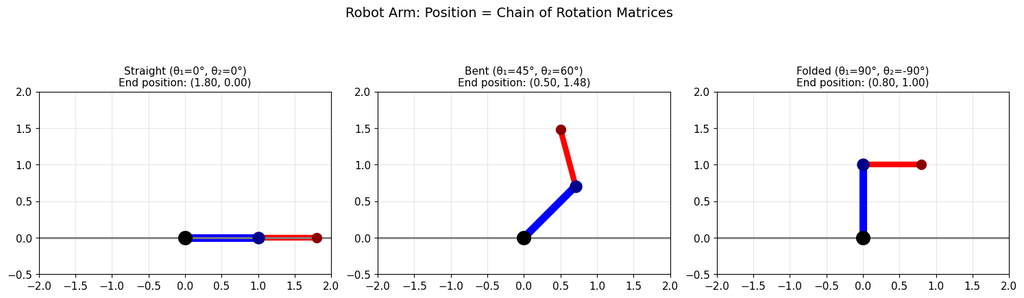

```python
def rotation_matrix(theta):
    """2D rotation matrix for angle theta (radians)."""
    return np.array([
        [np.cos(theta), -np.sin(theta)],
        [np.sin(theta), np.cos(theta)]
    ])

def plot_robot_arm(theta1, theta2, L1=1.0, L2=0.8):
    """Plot a 2-link robot arm."""
    # Base is at origin
    base = np.array([0, 0])

    # Joint 1: rotate arm1 direction by theta1
    R1 = rotation_matrix(theta1)
    arm1_direction = np.array([L1, 0])  # Initially pointing right
    arm1_end = base + R1 @ arm1_direction  # = joint2 position

    # Joint 2: rotate from joint1's frame by theta2
    R2 = rotation_matrix(theta1 + theta2)  # Total rotation
    arm2_direction = np.array([L2, 0])
    arm2_end = arm1_end + R2 @ arm2_direction  # = end effector

    return base, arm1_end, arm2_end

# Show robot arm at different configurations
fig, axes = plt.subplots(1, 3, figsize=(15, 5))

configs = [
    (0, 0, "Straight (θ₁=0°, θ₂=0°)"),
    (np.pi/4, np.pi/3, "Bent (θ₁=45°, θ₂=60°)"),
    (np.pi/2, -np.pi/2, "Folded (θ₁=90°, θ₂=-90°)")
]

for ax, (t1, t2, title) in zip(axes, configs):
    base, joint, end = plot_robot_arm(t1, t2)

    # Draw arm segments
    ax.plot([base[0], joint[0]], [base[1], joint[1]], 'b-', linewidth=8, solid_capstyle='round')
    ax.plot([joint[0], end[0]], [joint[1], end[1]], 'r-', linewidth=6, solid_capstyle='round')

    # Draw joints
    ax.scatter([base[0]], [base[1]], s=200, c='black', zorder=5)
    ax.scatter([joint[0]], [joint[1]], s=150, c='darkblue', zorder=5)
    ax.scatter([end[0]], [end[1]], s=100, c='darkred', zorder=5)

    ax.set_xlim(-2, 2)
    ax.set_ylim(-0.5, 2)
    ax.set_aspect('equal')
    ax.grid(True, alpha=0.3)
    ax.set_title(f'{title}\nEnd position: ({end[0]:.2f}, {end[1]:.2f})', fontsize=11)
    ax.axhline(y=0, color='gray', linewidth=2)  # Ground

plt.suptitle('Robot Arm: Position = Chain of Rotation Matrices', fontsize=14)
plt.tight_layout()
plt.show()
```

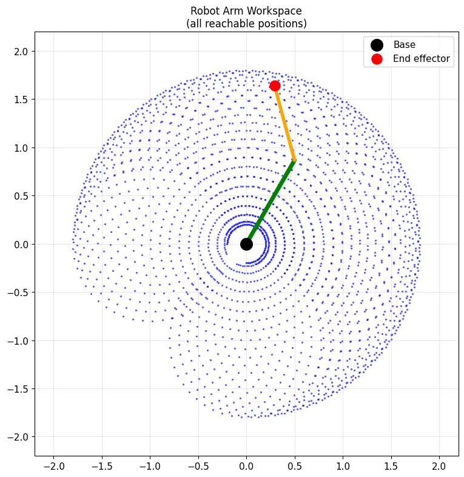

```
Key insight: Each joint rotation is a matrix multiplication!
The end position = Base + R(θ₁)·arm1 + R(θ₁+θ₂)·arm2
```

```python
# Show the workspace (reachable positions)
fig, ax = plt.subplots(figsize=(8, 8))

# Sample many configurations
n_samples = 50
theta1_range = np.linspace(-np.pi/2, np.pi, n_samples)
theta2_range = np.linspace(-np.pi, np.pi, n_samples)

end_positions = []
for t1 in theta1_range:
    for t2 in theta2_range:
        _, _, end = plot_robot_arm(t1, t2)
        end_positions.append(end)

end_positions = np.array(end_positions)
ax.scatter(end_positions[:, 0], end_positions[:, 1], s=2, alpha=0.5, c='blue')

# Draw a sample arm
base, joint, end = plot_robot_arm(np.pi/3, np.pi/4)
ax.plot([base[0], joint[0]], [base[1], joint[1]], 'g-', linewidth=5, solid_capstyle='round')
ax.plot([joint[0], end[0]], [joint[1], end[1]], 'orange', linewidth=4, solid_capstyle='round')
ax.scatter([base[0]], [base[1]], s=200, c='black', zorder=5, label='Base')
ax.scatter([end[0]], [end[1]], s=150, c='red', zorder=5, label='End effector')

ax.set_xlim(-2.2, 2.2)
ax.set_ylim(-2.2, 2.2)
ax.set_aspect('equal')
ax.grid(True, alpha=0.3)
ax.set_title('Robot Arm Workspace\n(all reachable positions)', fontsize=12)
ax.legend()

plt.tight_layout()
plt.show()

print("Key insight: Each joint rotation is a matrix multiplication!")
print("The end position = Base + R(θ₁)·arm1 + R(θ₁+θ₂)·arm2")
```

## 3. Columns Show Where Basis Vectors Go

**Key insight**: The columns of $\mathbf{A}$ show where the standard basis vectors land:

- Column 1 = where $\mathbf{e}_1 = [1, 0]^T$ goes
- Column 2 = where $\mathbf{e}_2 = [0, 1]^T$ goes

This completely determines the transformation!

```python
# Demonstrate: columns are transformed basis vectors
A = np.array([[2, -1],
              [1, 1.5]])

e1 = np.array([1, 0])
e2 = np.array([0, 1])

print(f"Matrix A:")
print(A)
print(f"\nWhere do basis vectors go?")
print(f"  A @ e1 = A @ [1,0] = {A @ e1}  ← This is column 1 of A!")
print(f"  A @ e2 = A @ [0,1] = {A @ e2}  ← This is column 2 of A!")
print(f"\nSo the columns of A literally tell you where [1,0] and [0,1] end up.")
```

```
Matrix A:
[[ 2.  -1. ]
 [ 1.   1.5]]

Where do basis vectors go?
  A @ e1 = A @ [1,0] = [2. 1.]  ← This is column 1 of A!
  A @ e2 = A @ [0,1] = [-1.   1.5]  ← This is column 2 of A!

So the columns of A literally tell you where [1,0] and [0,1] end up.
```

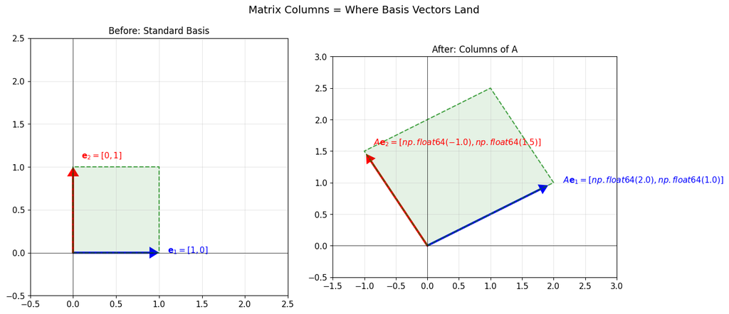

```python
# Visualize this insight
fig, axes = plt.subplots(1, 2, figsize=(14, 6))

# Before transformation
ax1 = axes[0]
ax1.arrow(0, 0, 0.9, 0, head_width=0.1, head_length=0.08, fc='blue', ec='blue', linewidth=2.5)
ax1.arrow(0, 0, 0, 0.9, head_width=0.1, head_length=0.08, fc='red', ec='red', linewidth=2.5)
ax1.text(1.1, 0, '$\mathbf{e}_1 = [1, 0]$', fontsize=11, color='blue')
ax1.text(0.1, 1.1, '$\mathbf{e}_2 = [0, 1]$', fontsize=11, color='red')

# Draw unit square
square = np.array([[0, 1, 1, 0, 0], [0, 0, 1, 1, 0]])
ax1.plot(square[0], square[1], 'g--', linewidth=1.5, alpha=0.7)
ax1.fill(square[0], square[1], alpha=0.1, color='green')

ax1.set_xlim(-0.5, 2.5)
ax1.set_ylim(-0.5, 2.5)
ax1.set_aspect('equal')
ax1.grid(True, alpha=0.3)
ax1.axhline(y=0, color='black', linewidth=0.5)
ax1.axvline(x=0, color='black', linewidth=0.5)
ax1.set_title('Before: Standard Basis', fontsize=12)

# After transformation
ax2 = axes[1]
Ae1 = A @ e1
Ae2 = A @ e2

ax2.arrow(0, 0, Ae1[0]*0.9, Ae1[1]*0.9, head_width=0.12, head_length=0.1, fc='blue', ec='blue', linewidth=2.5)
ax2.arrow(0, 0, Ae2[0]*0.9, Ae2[1]*0.9, head_width=0.12, head_length=0.1, fc='red', ec='red', linewidth=2.5)
ax2.text(Ae1[0]+0.15, Ae1[1], f'$A\mathbf{{e}}_1 = {list(Ae1)}$', fontsize=11, color='blue')
ax2.text(Ae2[0]+0.15, Ae2[1]+0.1, f'$A\mathbf{{e}}_2 = {list(Ae2)}$', fontsize=11, color='red')

# Draw transformed square (parallelogram)
transformed_square = A @ square
ax2.plot(transformed_square[0], transformed_square[1], 'g--', linewidth=1.5, alpha=0.7)
ax2.fill(transformed_square[0], transformed_square[1], alpha=0.1, color='green')

ax2.set_xlim(-1.5, 3)
ax2.set_ylim(-0.5, 3)
ax2.set_aspect('equal')
ax2.grid(True, alpha=0.3)
ax2.axhline(y=0, color='black', linewidth=0.5)
ax2.axvline(x=0, color='black', linewidth=0.5)
ax2.set_title('After: Columns of A', fontsize=12)

plt.suptitle('Matrix Columns = Where Basis Vectors Land', fontsize=14)
plt.tight_layout()
plt.show()
```

## 4. Special Matrices and Their Effects

| Matrix Type | Form | Effect |
| --- | --- | --- |
| Identity | $\mathbf{I}$ | No change |
| Diagonal | $\text{diag}(d_1, d_2)$ | Scale each axis independently |
| Rotation | $\begin{pmatrix} \cos\theta & -\sin\theta \\ \sin\theta & \cos\theta \end{pmatrix}$ | Rotate by angle $\theta$ |
| Symmetric | $\mathbf{A} = \mathbf{A}^T$ | Scale along orthogonal eigenvector directions |

```python
# Symmetric matrices scale along eigenvector directions
A_symmetric = np.array([[2, 1], [1, 2]])  # Symmetric!

# Find eigenvectors (principal directions)
eigenvalues, eigenvectors = np.linalg.eigh(A_symmetric)

print("Symmetric Matrix A:")
print(A_symmetric)
print(f"\nEigenvalues: {eigenvalues}")
print(f"Eigenvector 1: {eigenvectors[:, 0].round(3)} (scaled by {eigenvalues[0]})")
print(f"Eigenvector 2: {eigenvectors[:, 1].round(3)} (scaled by {eigenvalues[1]})")
print(f"\nEigenvectors are orthogonal: v1·v2 = {eigenvectors[:, 0] @ eigenvectors[:, 1]:.6f}")
```

```
Symmetric Matrix A:
[[2 1]
 [1 2]]

Eigenvalues: [1. 3.]
Eigenvector 1: [-0.707  0.707] (scaled by 1.0)
Eigenvector 2: [0.707 0.707] (scaled by 3.0)

Eigenvectors are orthogonal: v1·v2 = 0.000000
```

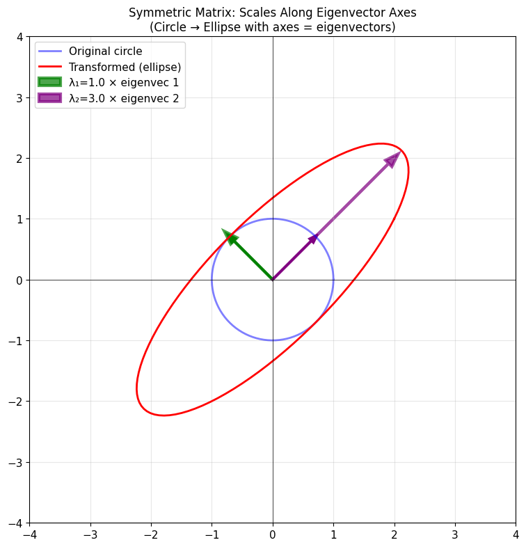

```python
# Visualize symmetric matrix transformation
fig, ax = plt.subplots(figsize=(8, 8))

# Plot transformation of unit circle
theta = np.linspace(0, 2*np.pi, 100)
circle = np.array([np.cos(theta), np.sin(theta)])
ellipse = A_symmetric @ circle

ax.plot(circle[0], circle[1], 'b-', linewidth=2, alpha=0.5, label='Original circle')
ax.plot(ellipse[0], ellipse[1], 'r-', linewidth=2, label='Transformed (ellipse)')

# Plot eigenvectors (they show the axes of the ellipse!)
v1, v2 = eigenvectors[:, 0], eigenvectors[:, 1]
ax.arrow(0, 0, v1[0]*0.9, v1[1]*0.9, head_width=0.1, fc='green', ec='green', linewidth=2)
ax.arrow(0, 0, v2[0]*0.9, v2[1]*0.9, head_width=0.1, fc='purple', ec='purple', linewidth=2)

# Show where eigenvectors go (they just get scaled!)
Av1 = A_symmetric @ v1
Av2 = A_symmetric @ v2
ax.arrow(0, 0, Av1[0]*0.9, Av1[1]*0.9, head_width=0.15, fc='green', ec='green',
         linewidth=3, alpha=0.7, label=f'λ₁={eigenvalues[0]:.1f} × eigenvec 1')
ax.arrow(0, 0, Av2[0]*0.9, Av2[1]*0.9, head_width=0.15, fc='purple', ec='purple',
         linewidth=3, alpha=0.7, label=f'λ₂={eigenvalues[1]:.1f} × eigenvec 2')

ax.set_xlim(-4, 4)
ax.set_ylim(-4, 4)
ax.set_aspect('equal')
ax.grid(True, alpha=0.3)
ax.axhline(y=0, color='black', linewidth=0.5)
ax.axvline(x=0, color='black', linewidth=0.5)
ax.legend(loc='upper left')
ax.set_title('Symmetric Matrix: Scales Along Eigenvector Axes\n(Circle → Ellipse with axes = eigenvectors)', fontsize=12)

plt.tight_layout()
plt.show()
```

## Key Takeaways

1. **Matrix-vector multiplication** $\mathbf{Ax}$ transforms vector $\mathbf{x}$
2. **Two equivalent views**:
   - Row view: each output element is a dot product
   - Column view: output is a linear combination of columns
3. **Columns of A** show where basis vectors land
   - Column $j$ = $\mathbf{A} \mathbf{e}_j$
   - This completely determines the transformation
4. **Geometric effects**:
   - Rotation: preserves lengths and angles
   - Scaling: stretches/shrinks along axes
   - Symmetric matrices: scale along orthogonal eigenvector directions
5. **Applications**: Robot kinematics, graphics, neural networks, coordinate transforms

**Next**: We'll explore **matrix-matrix multiplication** — composing transformations.